# latest

## A Project on Exploring Bitcoin Prices

In this project, we study **Bitcoin’s price dynamics** and construct **predictive, tradable signals** derived from its historical behaviour.  
Instead of attempting to forecast exact future price which is highly volatile and non-stationary, we focus on modelling **returns and directional trends**, translating these signals into **algorithmic trading rules**.

Our approach is benchmarked against a simple `Buy & Hold` strategy, with an emphasis on **risk-adjusted performance** rather than raw prediction accuracy.

Although level-error metrics such as **RMSE**, **MAE**, and **MAPE** are useful for evaluating forecasting models, our primary objective is **tradability**.  
Hence, we use the **Sharpe Ratio**, a measure of return per unit of risk, as our main performance metric.  
A higher Sharpe ratio indicates a more efficient strategy, and our goal is to achieve a **Sharpe ratio exceeding that of the Buy & Hold benchmark**.

The Sharpe Ratio is defined as:

$$\text{Sharpe Ratio} = \frac{E[R_p - R_f]}{\sigma_p}$$

where

- $( R_p )$ = portfolio or strategy return,
- $( R_f )$ = risk-free rate (often assumed 0 for crypto),
- $( \sigma_p )$ = standard deviation of portfolio returns.

In this academic exercise, we evaluate **two trading strategies** based on predicted Bitcoin returns:

#### 1. `Long Only` Strategy

This strategy takes a **long position** (buys Bitcoin) only when the predicted future return is **positive**:

$\hat{r}_{t+1} > 0 \ \Rightarrow \ \text{Go Long (Buy)}$

and holds **cash** (no position) when the predicted return is **negative**:

$\hat{r}_{t+1} \le 0 \ \Rightarrow \ \text{Stay Flat (Sell to Cash)}$

#### 2. `Long and Short` Strategy

This strategy allows positions on **both sides of the market**:

$\hat{r}_{t+1} > 0 \ \Rightarrow \ \text{Go Long (Buy)}$

$\hat{r}_{t+1} < 0 \ \Rightarrow \ \text{Go Short (Sell BTC)}$

Thus, the model continuously maintains exposure—either long or short—based on its predicted return signal.

For simplicity, we **assume no trading fees, slippage, or transaction costs**.

```python
import pandas as pd
import numpy as np
import matplotlib.pyplot as plt
import yfinance as yf
from sklearn.metrics import mean_squared_error, mean_absolute_error, root_mean_squared_error
from statsmodels.tsa.arima.model import ARIMA
from statsmodels.tsa.stattools import adfuller
import statsmodels.api as sm
import warnings
import requests

from sklearn.linear_model import LinearRegression
from sklearn.linear_model import LassoCV
from sklearn.linear_model import RidgeCV
from sklearn.linear_model import QuantileRegressor
import warnings
warnings.filterwarnings("ignore")
```

## Data cleaning and preprocessing

We will primarily use Bitcoin returns data only and briefly explore if gold and snp prices are good predictors for future BTC performance.

```python
btc_gold_sp = pd.read_csv('daily_btc_gold_snp.csv')
btc_gold_sp = btc_gold_sp.rename(columns = {
    'Price' : 'date',
    'Close' : 'btc_close',
    'Close.1' : 'gold_close',
    'Close.2' : 'snp_close'
})
btc_gold_sp_close = btc_gold_sp[['date', 'btc_close', 'gold_close', 'snp_close']]
btc_gold_sp_close = btc_gold_sp_close[2:]
btc_gold_sp_close[['gold_close', 'snp_close']] = btc_gold_sp_close[['gold_close', 'snp_close']].ffill()
btc_gold_sp_close_cleaned = btc_gold_sp_close.copy()
#btc_gold_sp_close_cleaned = btc_gold_sp_close.loc[btc_gold_sp_close['date'] >= '2023-01-01'].copy()
btc_gold_sp_close_cleaned['date'] = pd.to_datetime(btc_gold_sp_close_cleaned['date'])
btc_gold_sp_close_cleaned['btc_close'] = pd.to_numeric(btc_gold_sp_close_cleaned['btc_close'])
btc_gold_sp_close_cleaned['gold_close'] = pd.to_numeric(btc_gold_sp_close_cleaned['gold_close'])
btc_gold_sp_close_cleaned['snp_close'] = pd.to_numeric(btc_gold_sp_close_cleaned['snp_close'])
returns_dict = {
    'btc_close' : 'btc_return',
    'gold_close' : 'gold_return',
    'snp_close' : 'snp_return'
}

for key, value in returns_dict.items():
    first_price = btc_gold_sp_close_cleaned[key].iloc[0]
    btc_gold_sp_close_cleaned[value] = btc_gold_sp_close_cleaned[key].pct_change()
btc_gold_sp_close_cleaned = btc_gold_sp_close_cleaned.loc[btc_gold_sp_close['date'] >= '2023-01-01'].copy()
btc_gold_sp_close_cleaned_returns = btc_gold_sp_close_cleaned[['date'] + list(returns_dict.values())].copy()
btc_gold_sp_close_cleaned_returns

# add btc_close
btc_gold_sp_close_cleaned_returns['btc_close'] = btc_gold_sp_close_cleaned['btc_close'].values

btc_gold_sp_close_cleaned_returns
```

|  | date | btc_return | gold_return | snp_return | btc_close |
| --- | --- | --- | --- | --- | --- |
| 456 | 2023-01-01 | 0.004689 | 0.000000 | 0.000000 | 16625.080078 |
| 457 | 2023-01-02 | 0.003813 | 0.000000 | 0.000000 | 16688.470703 |
| 458 | 2023-01-03 | -0.000516 | 0.010991 | -0.004001 | 16679.857422 |
| 459 | 2023-01-04 | 0.010994 | 0.007121 | 0.007539 | 16863.238281 |
| 460 | 2023-01-05 | -0.001572 | -0.009715 | -0.011646 | 16836.736328 |
| ... | ... | ... | ... | ... | ... |
| 1459 | 2025-09-30 | -0.003010 | 0.005208 | 0.004091 | 114056.085938 |
| 1460 | 2025-10-01 | 0.040268 | 0.006952 | 0.003400 | 118648.929688 |
| 1461 | 2025-10-02 | 0.017129 | -0.007188 | 0.000618 | 120681.257812 |
| 1462 | 2025-10-03 | 0.013136 | 0.010704 | 0.000066 | 122266.531250 |
| 1463 | 2025-10-04 | 0.001496 | 0.000000 | 0.000000 | 122449.429688 |

1008 rows × 5 columns

### Data Selection and Period of Analysis

We use **daily Bitcoin price data** spanning from **2023 to 2025** for this study.

The dataset is divided as follows:

- **Training period:** 2023–2024
- **Testing period:** 2025

We begin our sample from **2023** to avoid potential **spillover effects from the COVID-19 pandemic**, which introduced extreme market volatility and structural breaks in earlier years (2020–2022).  
By focusing on more recent data, we aim to capture a **representative post-pandemic regime** of Bitcoin market behavior.

All data are assumed to be **chronologically ordered** and **non-overlapping** between training and testing sets.

```python
btc_returns = btc_gold_sp_close_cleaned_returns[['date', 'btc_return']].copy()
btc_returns
```

|  | date | btc_return |
| --- | --- | --- |
| 456 | 2023-01-01 | 0.004689 |
| 457 | 2023-01-02 | 0.003813 |
| 458 | 2023-01-03 | -0.000516 |
| 459 | 2023-01-04 | 0.010994 |
| 460 | 2023-01-05 | -0.001572 |
| ... | ... | ... |
| 1459 | 2025-09-30 | -0.003010 |
| 1460 | 2025-10-01 | 0.040268 |
| 1461 | 2025-10-02 | 0.017129 |
| 1462 | 2025-10-03 | 0.013136 |
| 1463 | 2025-10-04 | 0.001496 |

1008 rows × 2 columns

### Stationarity Check: Rolling Statistics and ADF Test

Before applying any predictive time series or machine learning models, it is important to understand the **statistical properties** of the Bitcoin returns series.

In particular, we examine whether the return series is **stationary**, i.e., whether its statistical characteristics (mean and variance) remain **constant over time**.

#### 1. Rolling Mean and Standard Deviation

We compute and plot the **30-day rolling mean** and **rolling standard deviation** of Bitcoin returns.  
This allows us to **visually inspect** how the average return and volatility evolve over time.

If these rolling statistics fluctuate substantially, it indicates that the series is **non-stationary**, which may lead to **biased model estimates** and **spurious correlations**.

$$\text{Rolling Mean at time } t = \frac{1}{k} \sum_{i=t-k+1}^{t} r_i$$

$$\text{Rolling Std at time } t = \sqrt{\frac{1}{k-1}\sum_{i=t-k+1}^{t}(r_i - \bar{r})^2}$$ where $( k = 30 )$ days.

#### 2. Augmented Dickey–Fuller (ADF) Test

To statistically test for stationarity, we apply the **Augmented Dickey–Fuller test**, which tests the null hypothesis:

$$ H_0: \text{The series has a unit root (non-stationary)} \\ H_1: \text{The series is stationary} $$

- If the **p-value < 0.05**, we reject $( H_0 )$ and conclude the series is **stationary**.
- If the **p-value > 0.05**, we fail to reject $( H_0 )$, suggesting the series is **non-stationary**.

#### 3. Interpretation

If the Bitcoin returns are found to be **non-stationary**, we may need to apply transformations such as **differencing**, **log-returns**, or **standardization** before modeling.  
Ensuring stationarity is crucial because most statistical and machine learning models assume that the underlying data distribution does **not change over time**.

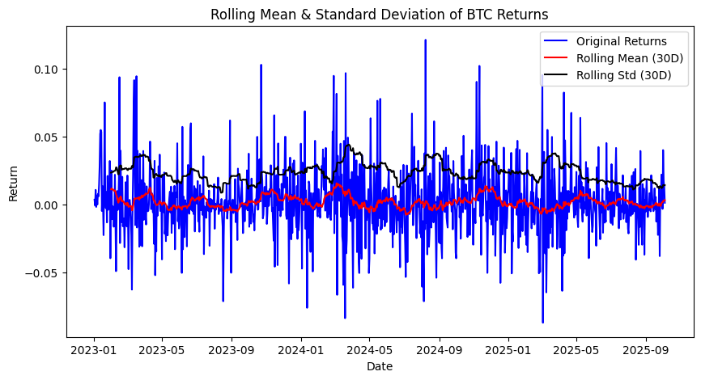

```
Results of Augmented Dickey-Fuller Test:
ADF Statistic: -21.8092
p-value: 0.0000
Used Lags: 1
Number of Observations: 1005
Critical Values:
    1%: -3.4369
    5%: -2.8644
    10%: -2.5683

✅ The series is stationary (reject H₀ of unit root).
```

```python
# 1. Compute rolling statistics
btc_returns_rolling = btc_returns[1:].copy()
rolling_mean = btc_returns_rolling["btc_return"].rolling(window=30).mean()
rolling_std = btc_returns_rolling["btc_return"].rolling(window=30).std()

# 2. Plot rolling mean and standard deviation
plt.figure(figsize=(10, 5))
plt.plot(btc_returns_rolling["date"], btc_returns_rolling["btc_return"], color='blue', label='Original Returns')
plt.plot(btc_returns_rolling["date"], rolling_mean, color='red', label='Rolling Mean (30D)')
plt.plot(btc_returns_rolling["date"], rolling_std, color='black', label='Rolling Std (30D)')
plt.title('Rolling Mean & Standard Deviation of BTC Returns')
plt.xlabel('Date')
plt.ylabel('Return')
plt.legend()
plt.show()

# 3. Perform Augmented Dickey-Fuller test
adf_stat, p_value, usedlag, nobs, crit_vals, icbest = adfuller(btc_returns_rolling["btc_return"], autolag='AIC')

print('Results of Augmented Dickey-Fuller Test:')
print(f'ADF Statistic: {adf_stat:.4f}')
print(f'p-value: {p_value:.4f}')
print(f'Used Lags: {usedlag}')
print(f'Number of Observations: {nobs}')
print('Critical Values:')
for key, value in crit_vals.items():
    print(f'    {key}: {value:.4f}')

## p value > 0.05, our returns is definitely not stationary

# 4. Interpret the results
if p_value < 0.05:
    print("\n✅ The series is stationary (reject H₀ of unit root).")
else:
    print("\n⚠️ The series is non-stationary (fail to reject H₀). Consider differencing or log-transforming.")
```

### Stationarity Confirmation and Strategy Evaluation

Now that stationarity has been established, we proceed to define a **modular & reusable evaluation function** that automates the computation of key performance metrics and plots for our trading strategies.  
This function will allow us to systematically compare the effectiveness of different models and trading rules (e.g., *Long Only* and *Long & Short*) based on their risk-adjusted returns and predictive accuracy.

```python
import pandas as pd
import numpy as np
import matplotlib.pyplot as plt
import seaborn as sns
from sklearn.metrics import confusion_matrix, accuracy_score

def analyze_model_performance(test_df, y_test, y_pred, model_name='Model'):
    """Analyzes and plots model performance for two trading strategies."""

    # Calculate metrics for both strategies
    long_only_returns = np.where(y_pred > 0, y_test, 0)
    long_and_short_returns = np.sign(y_pred) * y_test

    long_only_sharpe = (long_only_returns.mean() / long_only_returns.std()) * np.sqrt(252)
    long_short_sharpe = (long_and_short_returns.mean() / long_and_short_returns.std()) * np.sqrt(252)
    buy_hold_sharpe = (y_test.mean() / y_test.std()) * np.sqrt(252)

    y_test_sign = (y_test > 0).astype(int)
    y_pred_sign = (y_pred > 0).astype(int)
    accuracy = accuracy_score(y_test_sign, y_pred_sign)
    cm = confusion_matrix(y_test_sign, y_pred_sign)

    # Print summary
    print(f"--- Performance for {model_name} ---")
    print(f"Sharpe Ratio (Long Only): {long_only_sharpe:.3f}")
    print(f"Sharpe Ratio (Long & Short): {long_short_sharpe:.3f}")
    print(f"Sharpe Ratio (Buy and Hold): {buy_hold_sharpe:.3f}")
    print(f"Directional Accuracy: {accuracy*100:.2f}%\n")
    print("Confusion Matrix:\n", cm)
    print("-" * 30)

    # Plot actual vs. predicted returns
    plt.figure(figsize=(12, 6))
    plt.plot(test_df['date'], y_test, label='Actual Returns', alpha=0.7)
    plt.plot(test_df['date'], y_pred, label='Predicted Returns', alpha=0.7, linestyle='--')
    plt.title(f"Return Prediction ({model_name})")
    plt.xlabel("Date")
    plt.ylabel("Return")
    plt.legend()
    plt.show()

    # Plot cumulative returns for both strategies
    plot_df = test_df.copy()
    plot_df['Long_Only_Return'] = long_only_returns
    plot_df['Long_Short_Return'] = long_and_short_returns
    plot_df['Cum_Actual'] = (1 + plot_df['Next_Return']).cumprod()
    plot_df['Cum_Long_Only'] = (1 + plot_df['Long_Only_Return']).cumprod()
    plot_df['Cum_Long_Short'] = (1 + plot_df['Long_Short_Return']).cumprod()

    plt.figure(figsize=(12, 6))
    plt.plot(plot_df['date'], plot_df['Cum_Actual'], label='Buy and Hold')
    plt.plot(plot_df['date'], plot_df['Cum_Long_Only'], label='Long Only Strategy', linestyle='--')
    plt.plot(plot_df['date'], plot_df['Cum_Long_Short'], label='Long & Short Strategy', linestyle=':')
    plt.title(f"Cumulative Returns Comparison ({model_name})")
    plt.xlabel("Date")
    plt.ylabel("Cumulative Return")
    plt.legend()
    plt.show()

    # Plot confusion matrix
    plt.figure(figsize=(6, 5))
    sns.heatmap(cm, annot=True, fmt='d', cmap='Blues',
                xticklabels=['Predicted Down', 'Predicted Up'],
                yticklabels=['Actual Down', 'Actual Up'])
    plt.title(f'Directional Prediction Confusion Matrix ({model_name})')
    plt.xlabel('Predicted Direction')
    plt.ylabel('Actual Direction')
    plt.show()

    return {
        'long_only_sharpe': long_only_sharpe,
        'long_short_sharpe': long_short_sharpe,
        'buy_hold_sharpe': buy_hold_sharpe,
        'accuracy': accuracy
    }
```

### Linear Regression Model with 14-Day Lag Features

We begin with the **most basic predictive model — Linear Regression** — to test whether there exists any **linear relationship** between past Bitcoin returns and future returns.  
This serves as a baseline model to examine if short-term patterns (such as momentum or mean reversion) can be captured through simple linear dependencies.

Specifically, we use the **past 14 daily returns** as lagged explanatory variables to predict the next-day return:

$$ r_{t+1} = \beta_0 + \sum_{i=1}^{14} \beta_i \, r_{t-i} + \varepsilon_t $$

where

- $( r_{t+1} )$ is the next-day return,
- $( r_{t-i} )$ are lagged returns from the previous 14 days, and
- $( \varepsilon_t )$ is the error term.

#### Justification for the 14-Day Window

The **14-day lag** captures short-term market dynamics that often reflect momentum or reversal behavior over a two-week period.  
This time horizon is widely used in both **technical analysis** and **empirical finance**, where short-term momentum typically persists over **5–15 trading days**.

```
--- Performance for Linear Regression ---
Sharpe Ratio (Long Only): 1.089
Sharpe Ratio (Long & Short): 1.203
Sharpe Ratio (Buy and Hold): 0.855
Directional Accuracy: 51.45%

Confusion Matrix:
 [[ 23 113]
 [ 21 119]]
------------------------------
```

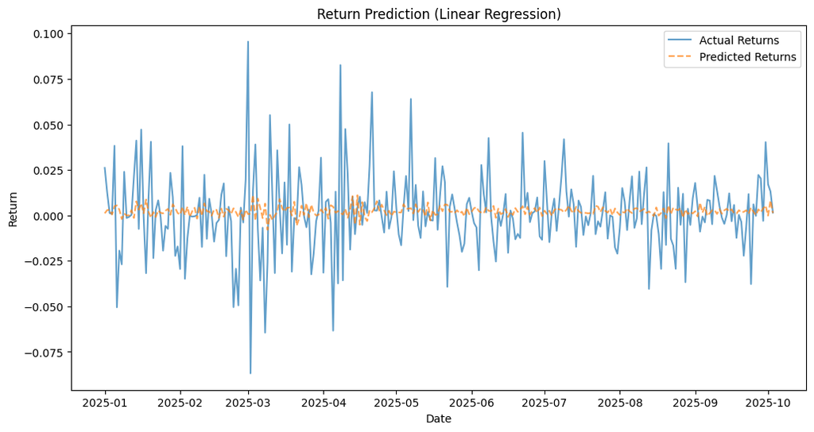

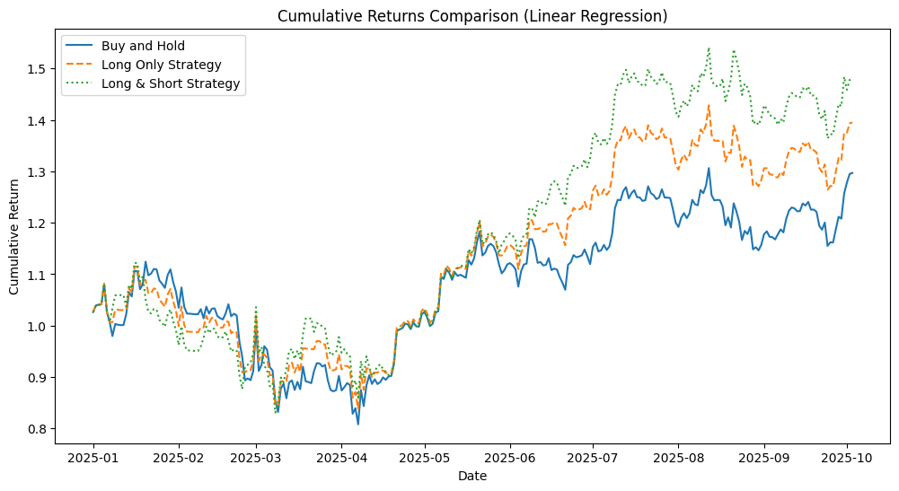

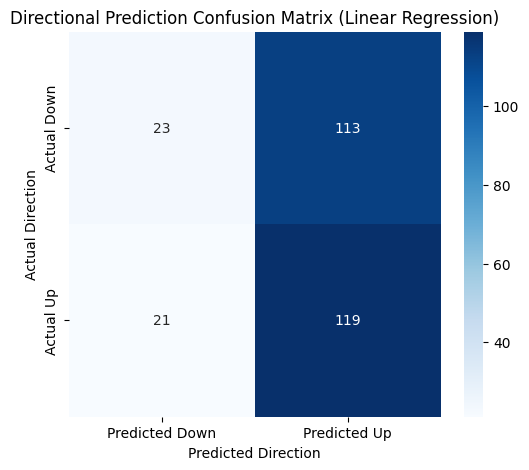

```python
import pandas as pd
import numpy as np
from sklearn.linear_model import LinearRegression

btc_returns_linear = btc_gold_sp_close_cleaned_returns[['date', 'btc_return']].copy()

num_lags = 14
for lag in range(1, num_lags + 1):
    btc_returns_linear[f'lag_{lag}'] = btc_returns_linear['btc_return'].shift(lag)

btc_returns_linear['Next_Return'] = btc_returns_linear['btc_return'].shift(-1)
btc_returns_linear = btc_returns_linear.dropna().reset_index(drop=True)

train_df = btc_returns_linear[btc_returns_linear['date'].between('2023-01-01', '2024-12-31')]
test_df = btc_returns_linear[btc_returns_linear['date'].between('2025-01-01', '2025-12-31')]

feature_cols = [f'lag_{i}' for i in range(1, num_lags + 1)]
X_train = train_df[feature_cols].values
y_train = train_df['Next_Return'].values
X_test = test_df[feature_cols].values
y_test = test_df['Next_Return'].values

model = LinearRegression()
model.fit(X_train, y_train)

y_pred = model.predict(X_test)
metrics = analyze_model_performance(test_df, y_test, y_pred, model_name='Linear Regression')
```

```
Best alpha: 0.4 with accuracy: 0.5144927536231884
--- Performance for Ridge Regression ---
Sharpe Ratio (Long Only): 0.895
Sharpe Ratio (Long & Short): 0.912
Sharpe Ratio (Buy and Hold): 0.855
Directional Accuracy: 51.45%

Confusion Matrix:
 [[  6 130]
 [  4 136]]
------------------------------
```

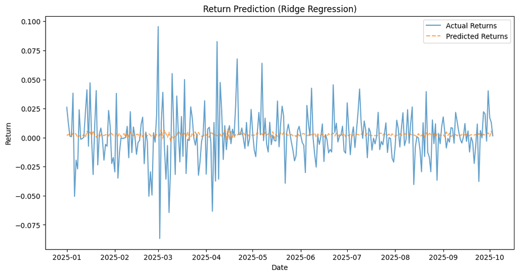

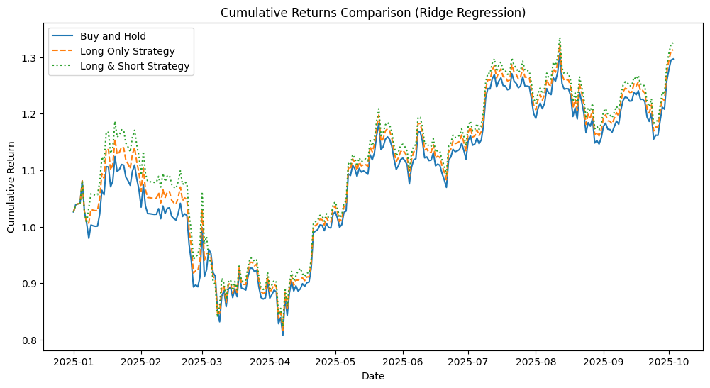

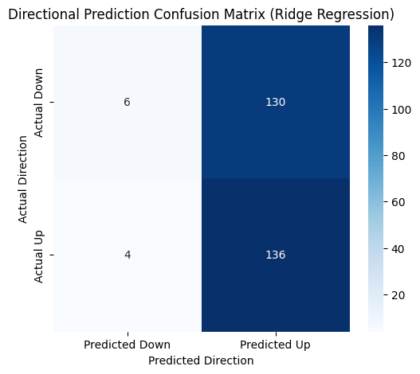

```
Metrics dictionary returned by the function:
{'long_only_sharpe': np.float64(0.8945621472811295), 'long_short_sharpe': np.float64(0.9121324206029733), 'buy_hold_sharpe': np.float64(0.8549789775309998), 'accuracy': 0.5144927536231884}
```

```python
import pandas as pd
import numpy as np
from sklearn.linear_model import Ridge

btc_returns_ridge = btc_gold_sp_close_cleaned_returns[['date', 'btc_return']].copy()

num_lags = 14
for lag in range(1, num_lags + 1):
    btc_returns_ridge[f'lag_{lag}'] = btc_returns_ridge['btc_return'].shift(lag)

btc_returns_ridge['Next_Return'] = btc_returns_ridge['btc_return'].shift(-1)
btc_returns_ridge = btc_returns_ridge.dropna().reset_index(drop=True)

train_df = btc_returns_ridge[btc_returns_ridge['date'].between('2023-01-01', '2024-12-31')]
test_df = btc_returns_ridge[btc_returns_ridge['date'].between('2025-01-01', '2025-12-31')]

feature_cols = [f'lag_{i}' for i in range(1, num_lags + 1)]
X_train = train_df[feature_cols].values
y_train = train_df['Next_Return'].values
X_test = test_df[feature_cols].values
y_test = test_df['Next_Return'].values

# grid search for alpha
best_alpha = None
best_score = float('-inf')
alphas = [0.01, 0.02, 0.03, 0.04, 0.05, 0.06, 0.07, 0.08, 0.09, 0.1, 0.2, 0.3, 0.4, 0.5, 0.6, 0.7, 0.8, 0.9, 1.0]
for alpha in alphas:
    model = Ridge(alpha=alpha)
    model.fit(X_train, y_train)
    y_pred = model.predict(X_test)
    accuracy = (np.sign(y_pred) == np.sign(y_test)).mean()
    if accuracy > best_score:
        best_score = accuracy
        best_alpha = alpha
print(f"Best alpha: {best_alpha} with accuracy: {best_score}")

model = Ridge(alpha=best_alpha)
model.fit(X_train, y_train)
y_pred = model.predict(X_test)


metrics = analyze_model_performance(test_df, y_test, y_pred, model_name='Ridge Regression')

print("\nMetrics dictionary returned by the function:")
print(metrics)
```

### Modeling with XGBoost

After testing linear regression, we apply **XGBoost**, a more powerful **nonlinear machine learning model** based on **gradient-boosted decision trees**.  
Unlike linear models, XGBoost can automatically capture **nonlinear patterns**, **interactions between lagged returns**, and **threshold effects** that may exist in Bitcoin price dynamics.

We use the previous **21 daily returns** as input features to predict the next-day return.  
This 21-day horizon (about one trading month) helps the model detect both **short- and medium-term momentum**.

Key properties of XGBoost:

- Learns complex nonlinear relationships without manual feature engineering.
- Handles noisy and unscaled data effectively (no need to standardize returns).
- Uses built-in regularization (`max_depth`, `n_estimators`) to reduce overfitting.

#### How Gradient Boosting Works

XGBoost builds a sequence of weak learners (decision trees) $(\{h_m(x)\}_{m=1}^{M})$,  
each one improving upon the residuals (errors) of the previous model:

$$ \hat{y}_i^{(m)} = \hat{y}_i^{(m-1)} + \eta \, h_m(x_i), $$

where

- $(\eta)$ is the **learning rate**,
- $(h_m(x))$ minimizes the gradient of the loss function with respect to model predictions.

The objective minimized by XGBoost is:

$$ \mathcal{L} = \sum_i l(y_i, \hat{y}_i) + \sum_m \Omega(h_m), $$

where

- $(l(y_i, \hat{y}_i))$ is the prediction loss (e.g., squared error),
- $(\Omega(h_m))$ is a **regularization term** that penalizes overly complex trees.

Finally, the model’s predictions are evaluated using the same trading strategy framework as before, comparing **Long Only**, **Long & Short**, and **Buy & Hold** performances via Sharpe ratio and directional accuracy.

```
--- Performance for XGBoost ---
Sharpe Ratio (Long Only): 1.073
Sharpe Ratio (Long & Short): 0.812
Sharpe Ratio (Buy and Hold): 0.855
Directional Accuracy: 52.17%

Confusion Matrix:
 [[66 70]
 [62 78]]
------------------------------
```

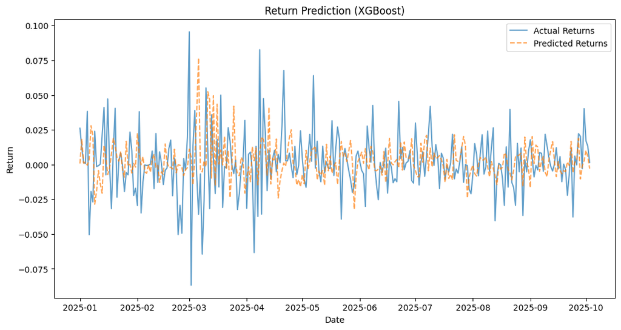

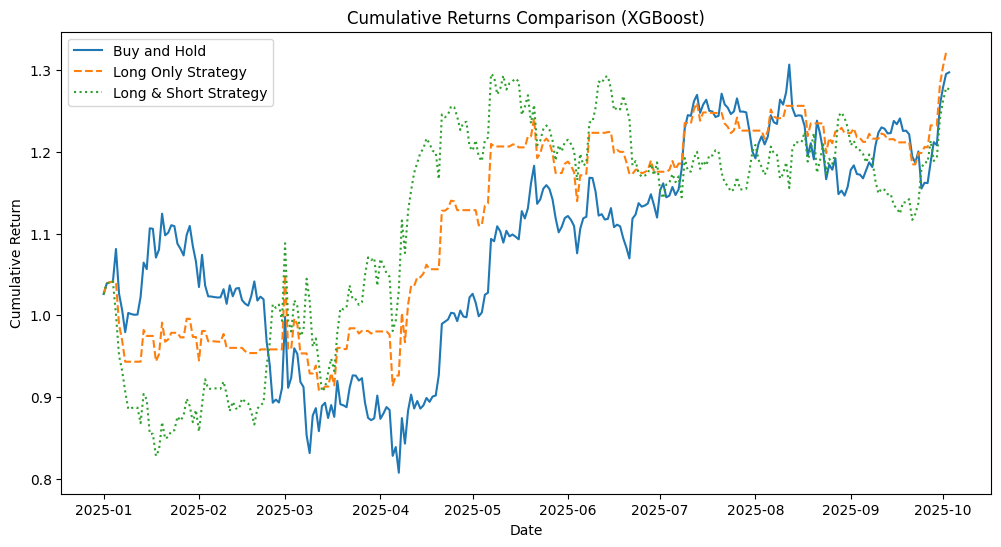

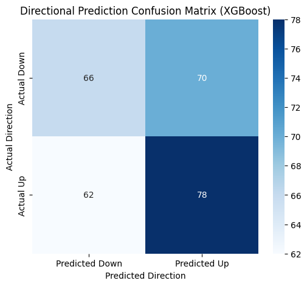

```
Metrics dictionary returned by the function:
{'long_only_sharpe': np.float64(1.0728968832968075), 'long_short_sharpe': np.float64(0.8123610319463164), 'buy_hold_sharpe': np.float64(0.8549789775309998), 'accuracy': 0.5217391304347826}
```

```python
import pandas as pd
import numpy as np
from xgboost import XGBRegressor
from sklearn.metrics import mean_squared_error, confusion_matrix, accuracy_score
import matplotlib.pyplot as plt
import seaborn as sns

btc_returns_xgb = btc_gold_sp_close_cleaned_returns[['date', 'btc_return']].copy()

num_lags = 21
for lag in range(1, num_lags + 1):
    btc_returns_xgb[f'lag_{lag}'] = btc_returns_xgb['btc_return'].shift(lag)

btc_returns_xgb['Next_Return'] = btc_returns_xgb['btc_return'].shift(-1)
btc_returns_xgb = btc_returns_xgb.dropna().reset_index(drop=True)

train_df = btc_returns_xgb[btc_returns_xgb['date'].between('2023-01-01', '2024-12-31')]
test_df = btc_returns_xgb[btc_returns_xgb['date'].between('2025-01-01', '2025-12-31')]

feature_cols = [f'lag_{i}' for i in range(1, num_lags + 1)]
X_train = train_df[feature_cols].values
y_train = train_df['Next_Return'].values
X_test = test_df[feature_cols].values
y_test = test_df['Next_Return'].values

# --- 2. Model Training and Prediction ---
model = XGBRegressor(n_estimators=100, max_depth=3, random_state=42, n_jobs=-1)
model.fit(X_train, y_train)
y_pred = model.predict(X_test)

# --- 3. Analysis and Visualization ---
# The entire block of analysis code is replaced by this single function call
metrics = analyze_model_performance(test_df, y_test, y_pred, model_name='XGBoost')

print("\nMetrics dictionary returned by the function:")
print(metrics)
```

### Neural Networks (ANN) for Next-Day Return Prediction

We extend beyond linear/tree models to a **feed-forward neural network (ANN)** that learns a nonlinear mapping from the past **21 daily returns** to the next-day return.  
Inputs are lag features $((r_{t-1},\ldots,r_{t-21}))$; the target is $(r_{t+1})$.

**Model form** $$ \hat{r}_{t+1} \;=\; f_\theta\!\big(r_{t-1}, r_{t-2}, \dots, r_{t-21}\big), $$ where $(f_\theta)$ is a multi-layer perceptron with ReLU activations and dropout regularization.

**Loss (training objective)** $$ \mathcal{L}_{\text{MSE}} \;=\; \frac{1}{N}\sum_{i=1}^{N}\big(\hat{r}_{i} - r_{i}\big)^2. $$

**Scaling**

- Features $(X)$ and target $(y)$ are **MinMax-scaled** for stable optimization.
- Predictions are **inverse-transformed** back to the original return scale before evaluation.

**Hyperparameter tuning (Keras Tuner)**

- Search over **hidden units**, **dropout rates**, and **learning rate** for Adam.
- Final model is retrained on the full training set with the best hyperparameters.

> This ANN captures **nonlinear** and **interaction** effects among lags that linear models may miss, while dropout and tuning help control overfitting on noisy daily return data.

```
Trial 10 Complete [00h 00m 16s]
val_loss: 0.016217365860939026

Best val_loss So Far: 0.015819592401385307
Total elapsed time: 00h 02m 53s

Best hyperparameters found:
- Layer 1 units: 224
- Layer 1 dropout: 0.10
- Layer 2 units: 16
- Layer 2 dropout: 0.40
- Learning Rate: 0.001

9/9 ━━━━━━━━━━━━━━━━━━━━ 0s 11ms/step
--- Performance for ANN ---
Sharpe Ratio (Long Only): 0.545
Sharpe Ratio (Long & Short): -0.010
Sharpe Ratio (Buy and Hold): 0.855
Directional Accuracy: 50.36%

Confusion Matrix:
 [[76 60]
 [77 63]]
------------------------------
```

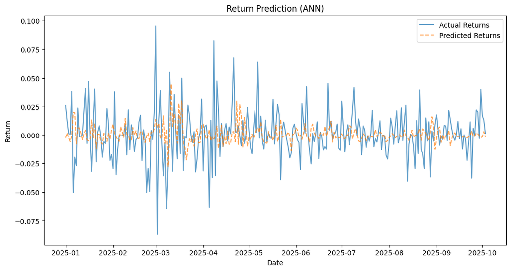

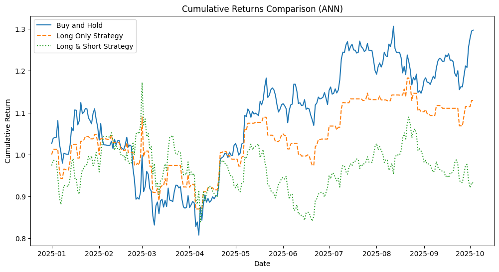

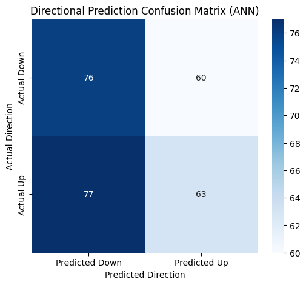

```
Metrics dictionary returned by the function:
{'long_only_sharpe': np.float64(0.5451775043863847), 'long_short_sharpe': np.float64(-0.00971975762415763), 'buy_hold_sharpe': np.float64(0.8549789775309998), 'accuracy': 0.5036231884057971}
```

```python
import pandas as pd
import numpy as np
import tensorflow as tf
import keras_tuner as kt
from tensorflow.keras.models import Sequential
from tensorflow.keras.layers import Dense, Dropout
from tensorflow.keras.optimizers import Adam
from sklearn.preprocessing import MinMaxScaler

data = btc_gold_sp_close_cleaned_returns[['date', 'btc_close', 'btc_return']].copy()
data['date'] = pd.to_datetime(data['date'])

num_lags = 21
for lag in range(1, num_lags + 1):
    data[f'lag_{lag}'] = data['btc_return'].shift(lag)

data['Next_Return'] = data['btc_return'].shift(-1)
data = data.dropna().reset_index(drop=True)

train_df = data[data['date'].between('2023-01-01', '2024-12-31')]
test_df = data[data['date'].between('2025-01-01', '2025-12-31')]

feature_cols = [f'lag_{i}' for i in range(1, num_lags + 1)]
X_train = train_df[feature_cols].values
y_train = train_df['Next_Return'].values
X_test = test_df[feature_cols].values
y_test = test_df['Next_Return'].values

# --- 2. Scale Both Feature (X) and Target (y) Data ---
x_scaler = MinMaxScaler()
X_train_scaled = x_scaler.fit_transform(X_train)
X_test_scaled = x_scaler.transform(X_test)

# Create a separate scaler for the target variable
y_scaler = MinMaxScaler()
y_train_scaled = y_scaler.fit_transform(y_train.reshape(-1, 1))

# --- 3. Hyperparameter Tuning Setup ---
def build_model(hp):
    model = Sequential()
    model.add(Dense(
        units=hp.Int('units_layer1', min_value=32, max_value=512, step=32),
        activation='relu',
        input_shape=(X_train_scaled.shape[1],)
    ))
    model.add(Dropout(rate=hp.Float('dropout_1', min_value=0.1, max_value=0.5, step=0.1)))
    model.add(Dense(
        units=hp.Int('units_layer2', min_value=16, max_value=64, step=16),
        activation='relu'
    ))
    model.add(Dropout(rate=hp.Float('dropout_2', min_value=0.1, max_value=0.5, step=0.1)))
    model.add(Dense(1))

    # Using a more appropriate range for learning rates
    hp_learning_rate = hp.Choice('learning_rate', values=[1e-3, 1e-4, 1e-5])

    model.compile(optimizer=Adam(learning_rate=hp_learning_rate),
                  loss='mean_squared_error')
    return model

tuner = kt.RandomSearch(
    build_model,
    objective='val_loss',
    max_trials=10,
    executions_per_trial=1,
    directory='my_dir_scaled', # Use a new directory for the new search
    project_name='btc_tuning_scaled'
)

# Train the tuner on the scaled target data
tuner.search(X_train_scaled, y_train_scaled, epochs=50, validation_split=0.2, verbose=1)

# --- 4. Get the Best Model and Make Predictions ---
best_hps = tuner.get_best_hyperparameters(num_trials=1)[0]
print(f"""
Best hyperparameters found:
- Layer 1 units: {best_hps.get('units_layer1')}
- Layer 1 dropout: {best_hps.get('dropout_1'):.2f}
- Layer 2 units: {best_hps.get('units_layer2')}
- Layer 2 dropout: {best_hps.get('dropout_2'):.2f}
- Learning Rate: {best_hps.get('learning_rate')}
""")

# Build and train the final model on the scaled target data
best_model = tuner.hypermodel.build(best_hps)
best_model.fit(X_train_scaled, y_train_scaled, epochs=100, batch_size=32, verbose=0)

# Predict scaled values and transform them back to the original scale
y_pred_scaled = best_model.predict(X_test_scaled)
y_pred = y_scaler.inverse_transform(y_pred_scaled).flatten()

# Analyze the real-scale predictions
metrics = analyze_model_performance(test_df, y_test, y_pred, model_name='ANN')

print("\nMetrics dictionary returned by the function:")
print(metrics)
```

### Multilayer Perceptron Regressor

Similar to the **feed-forward neural network (ANN)** method, we make want to map the past **21 daily returns** to the next-day return using machine learning model **multilayer perceptron (MLP) regressor**. Inputs are lag features $((r_{t-1},\ldots,r_{t-21}))$; the target is $(r_{t+1})$.

**Loss (training objective)**

- For learning and selection of hyperparameters, we made use of the Sharpe Ratio as our metric instead of a convention loss function.

**Scaling**

- Features $(X)$ and target $(y)$ are **MinMax-scaled** for stable optimization.
- Predictions are **inverse-transformed** back to the original return scale before evaluation.

**Hyperparameter tuning**

- Do a local search over **hidden layer sizes**, **alpha for L2 regularisation term**, **tolerance level** and **learning rate** for Adam.
- Final model is retrained on the full training set with the best hyperparameters.

```
Best hyperparameters found:
- Layer 1 units: 46
- Layer 2 units: 90
- Alpha: 0.0001
- Tolerance: 0.0001
- Learning Rate: 0.000630957344480193

--- Performance for MLP Regressor ---
Sharpe Ratio (Long Only): 2.218
Sharpe Ratio (Long & Short): 2.349
Sharpe Ratio (Buy and Hold): 0.855
Directional Accuracy: 55.43%

Confusion Matrix:
 [[71 65]
 [58 82]]
------------------------------
```

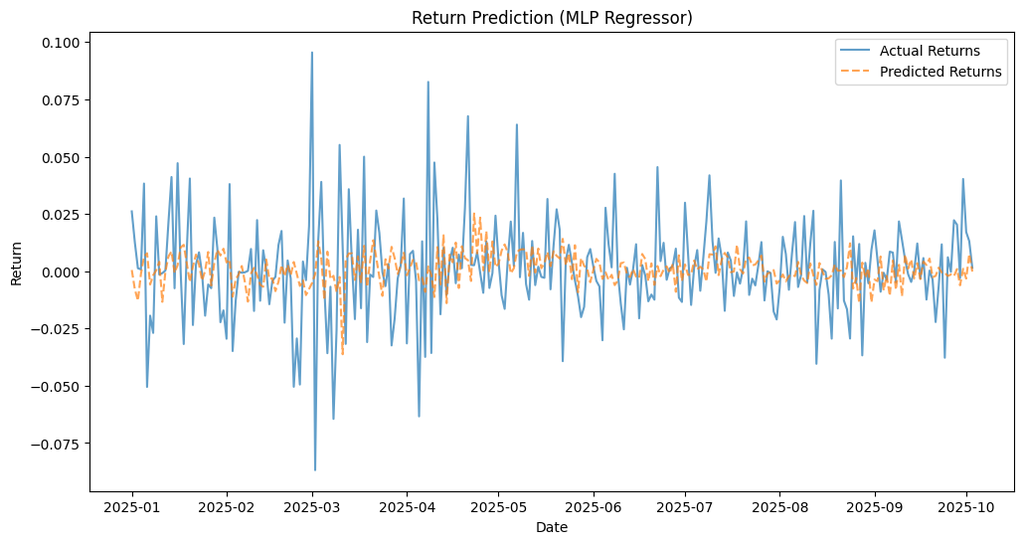

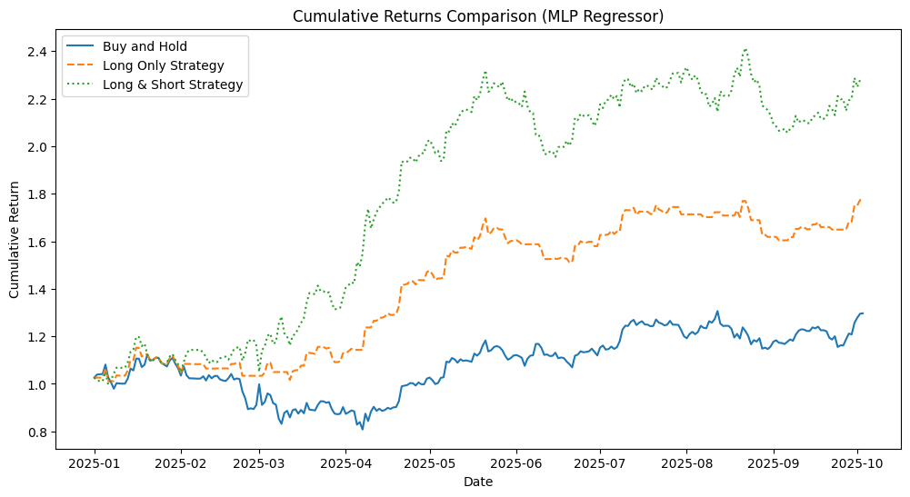

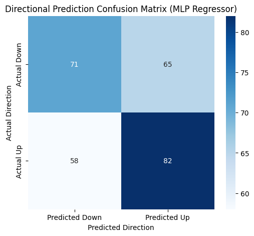

```
Metrics dictionary returned by the function:
{'long_only_sharpe': np.float64(2.218397793812117), 'long_short_sharpe': np.float64(2.3488147156830914), 'buy_hold_sharpe': np.float64(0.8549789775309998), 'accuracy': 0.5543478260869565}
```

```python
import pandas as pd
import numpy as np
from sklearn.neural_network import MLPRegressor
from sklearn.preprocessing import MinMaxScaler
from sklearn import metrics
import warnings
warnings.filterwarnings("ignore")

# --- 1. Data and Feature Engineering ---
# Select the returns from all three assets
data = btc_gold_sp_close_cleaned_returns[['date', 'btc_return', 'gold_return', 'snp_return']].copy()
data['date'] = pd.to_datetime(data['date'])

num_lags = 21
for lag in range(1, num_lags + 1):
    data[f'lag_{lag}'] = data['btc_return'].shift(lag)

# Create the target variable (Bitcoin's next-day return)
data['Next_Return'] = data['btc_return'].shift(-1)
data = data.dropna().reset_index(drop=True)

# --- 2. Training and Prediction ---
train_df = data[data['date'].between('2023-01-01', '2024-12-31')]
test_df = data[data['date'].between('2025-01-01', '2025-12-31')]

feature_cols = [f'lag_{i}' for i in range(1, num_lags + 1)]
X_train = train_df[feature_cols].values
y_train = train_df['Next_Return'].values
X_test = test_df[feature_cols].values
y_test = test_df['Next_Return'].values

# --- 3. Scale Both Feature (X) and Target (y) Data ---
x_scaler = MinMaxScaler()
X_train_scaled = x_scaler.fit_transform(X_train)
X_test_scaled = x_scaler.transform(X_test)

# Create a separate scaler for the target variable
y_scaler = MinMaxScaler()
y_train_scaled = y_scaler.fit_transform(y_train.reshape(-1, 1))

# --- 3. Hyperparameter Tuning Setup ---
model = MLPRegressor(random_state=99, max_iter=2000)

# Finding a local optimal hyper parameters using long and short strategy Sharpe Ratio as metric
# Get number of neurons of layers
best_sharpe = -100
best_i = None
best_j = None
for i in range(1, 101):
    for j in range(1, 101):
        model = MLPRegressor(random_state=99, hidden_layer_sizes=(i, j), max_iter=2000)
        model.fit(X_train_scaled, y_train_scaled)

        y_pred_scaled = model.predict(X_test_scaled)
        y_pred = y_scaler.inverse_transform(y_pred_scaled.reshape(-1, 1)).flatten()

        predicted_returns = y_pred
        actual_returns = y_test

        strategy_returns = np.sign(predicted_returns) * actual_returns

        sharpe = strategy_returns.mean() / strategy_returns.std() * np.sqrt(len(y_test))  # annualized
        if sharpe > best_sharpe:
            best_sharpe = sharpe
            best_i = i
            best_j = j

# Get alpha value
best_sharpe = -100
best_alpha = None
for alpha in np.logspace(-8,8,101):
    model = MLPRegressor(random_state=99, hidden_layer_sizes=(best_i, best_j), max_iter=1000, alpha=alpha)
    model.fit(X_train_scaled, y_train_scaled)

    y_pred_scaled = model.predict(X_test_scaled)
    y_pred = y_scaler.inverse_transform(y_pred_scaled.reshape(-1, 1)).flatten()

    predicted_returns = y_pred
    actual_returns = y_test

    strategy_returns = np.sign(predicted_returns) * actual_returns

    sharpe = strategy_returns.mean() / strategy_returns.std() * np.sqrt(len(y_test))  # annualized

    if sharpe > best_sharpe:
        best_sharpe = sharpe
        best_alpha = alpha

# Get tol value
best_sharpe = -100
best_tol = None
for tol1 in np.logspace(-8,8,101):
    model = MLPRegressor(random_state=99, hidden_layer_sizes=(best_i, best_j), max_iter=1000, tol=tol1, alpha=best_alpha)
    model.fit(X_train_scaled, y_train_scaled)

    y_pred_scaled = model.predict(X_test_scaled)
    y_pred = y_scaler.inverse_transform(y_pred_scaled.reshape(-1, 1)).flatten()

    predicted_returns = y_pred
    actual_returns = y_test

    strategy_returns = np.sign(predicted_returns) * actual_returns
    #strategy_returns = strategy_returns.apply(lambda x: max(0, x))

    sharpe = strategy_returns.mean() / strategy_returns.std() * np.sqrt(len(y_test))  # annualized

    if sharpe > best_sharpe:
        best_sharpe = sharpe
        best_tol = tol1

# Get learning rate value
best_sharpe = -100
best_lr = None
for lr in np.logspace(-8,8,101):
    model = MLPRegressor(random_state=99, hidden_layer_sizes=(best_i, best_j), max_iter=1000, tol=best_tol, alpha=best_alpha, learning_rate_init=lr)
    model.fit(X_train_scaled, y_train_scaled)

    y_pred_scaled = model.predict(X_test_scaled)
    y_pred = y_scaler.inverse_transform(y_pred_scaled.reshape(-1, 1)).flatten()

    predicted_returns = y_pred
    actual_returns = y_test

    strategy_returns = np.sign(predicted_returns) * actual_returns
    #strategy_returns = strategy_returns.apply(lambda x: max(0, x))

    sharpe = strategy_returns.mean() / strategy_returns.std() * np.sqrt(len(y_test))  # annualized

    if sharpe > best_sharpe:
        best_sharpe = sharpe
        best_lr = lr

# --- 4. Get the Best Model and Make Predictions ---
print(f"""
Best hyperparameters found:
- Layer 1 units: {best_i}
- Layer 2 units: {best_j}
- Alpha: {best_alpha}
- Tolerance: {best_tol}
- Learning Rate: {best_lr}
""")

# Build and train the final model on the scaled target data
best_model = MLPRegressor(random_state=99, hidden_layer_sizes=(best_i, best_j), max_iter=1000, tol=best_tol, alpha=best_alpha, learning_rate_init=best_lr)
best_model.fit(X_train_scaled, y_train_scaled)

# Predict scaled values and transform them back to the original scale
y_pred_scaled = best_model.predict(X_test_scaled)
y_pred = y_scaler.inverse_transform(y_pred_scaled.reshape(-1, 1)).flatten()

# Analyze the real-scale predictions
metrics = analyze_model_performance(test_df, y_test, y_pred, model_name='MLP Regressor')

print("\nMetrics dictionary returned by the function:")
print(metrics)
```

### Sequence Modeling with LSTM

We next apply a **Long Short-Term Memory (LSTM)** network, which models temporal dependencies by processing a **30-day window** of sequential inputs.  
Unlike feed-forward networks, the LSTM maintains an internal memory that learns how past market behavior influences future returns.

**Input–Target Setup**

Let the feature vector at day $t$ be:

$$ \mathbf{x}_t = [\text{btc\_return}_t,\ \text{volatility\_14,t},\ \text{rsi\_14,t}] $$

For each window of $n = 30$ days:

$$ \mathbf{X}_{t-n+1:t} = (\mathbf{x}_{t-n+1}, \ldots, \mathbf{x}_t) $$

The model predicts the next-day return as:

$$ \hat{r}_{t+1} = f_{\text{LSTM}}(\mathbf{X}_{t-n+1:t}) $$

where $f_{\text{LSTM}}$ is the nonlinear mapping learned by the network.

**Model Architecture**

- Two stacked LSTM layers (50 units each) with dropout regularization
- Dense output layer predicting $\hat{r}_{t+1}$
- Optimizer: Adam Loss: Mean Squared Error (MSE)

**Reason for 30-Day Window**

A 30-day lookback (~1 month) captures both **weekly momentum** and **medium-term volatility clustering**,  
while avoiding the overfitting risk associated with excessively long memory horizons.

**Preprocessing**

All input features and targets are **MinMax-scaled** for stable gradient updates.  
Predictions are **inverse-scaled** back to the original return scale before evaluation.

> The LSTM provides a more powerful temporal framework that can capture **sequence dependencies**  
> and **nonlinear relationships** that static models may overlook, offering a deeper test of whether Bitcoin returns exhibit any time-dependent predictability.

```
8/8 ━━━━━━━━━━━━━━━━━━━━ 1s 68ms/step
--- Performance for LSTM ---
Sharpe Ratio (Long Only): 1.275
Sharpe Ratio (Long & Short): 1.693
Sharpe Ratio (Buy and Hold): 0.701
Directional Accuracy: 53.25%

Confusion Matrix:
 [[ 24  98]
 [ 17 107]]
------------------------------
```

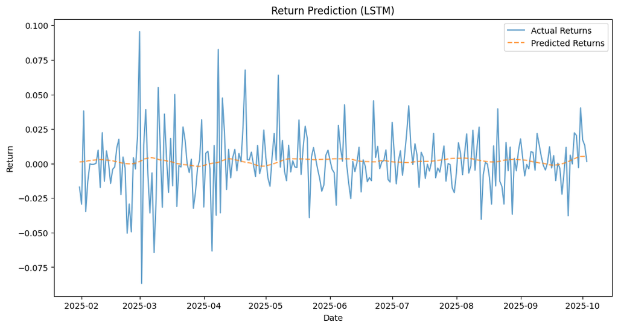

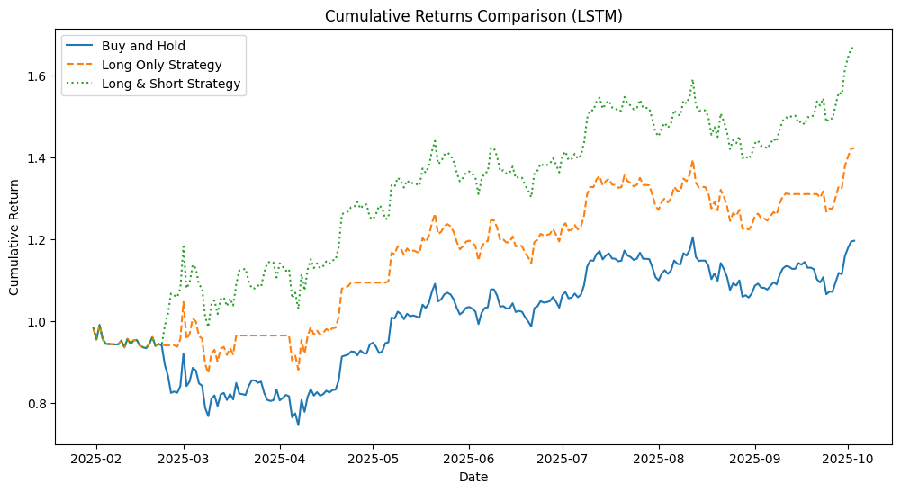

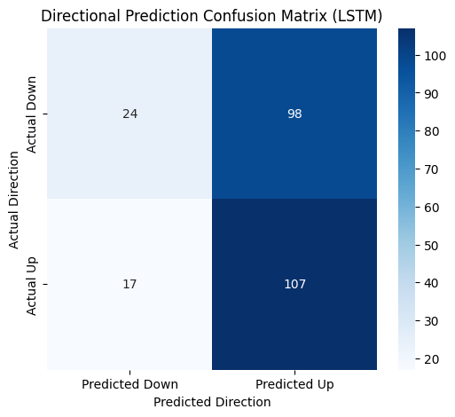

```
Metrics dictionary returned by the function:
{'long_only_sharpe': np.float64(1.2752745322253065), 'long_short_sharpe': np.float64(1.6929341483254672), 'buy_hold_sharpe': np.float64(0.7012185019140329), 'accuracy': 0.532520325203252}
```

```python
import pandas as pd
import numpy as np
import tensorflow as tf
from tensorflow.keras.models import Sequential
from tensorflow.keras.layers import LSTM, Dense, Dropout
from sklearn.preprocessing import MinMaxScaler

def create_sequences(data, n_steps):
    X, y = [], []
    for i in range(len(data)):
        end_ix = i + n_steps
        if end_ix > len(data) - 1:
            break
        # The input sequence is now all feature columns
        seq_x, seq_y = data[i:end_ix, :-1], data[end_ix, -1]
        X.append(seq_x)
        y.append(seq_y)
    return np.array(X), np.array(y)

# --- 1. Data and Feature Engineering ---
# Start with daily features, not lagged features
data = btc_gold_sp_close_cleaned_returns[['date', 'btc_close', 'btc_return']].copy()
data['date'] = pd.to_datetime(data['date'])

# Create a few daily technical indicators as features
data['volatility_14'] = data['btc_return'].rolling(window=14).std()
delta = data['btc_close'].diff()
gain = (delta.where(delta > 0, 0)).rolling(window=14).mean()
loss = (-delta.where(delta < 0, 0)).rolling(window=14).mean()
rs = gain / loss
data['rsi_14'] = 100 - (100 / (1 + rs))

# Create the target variable and clean the data
data['Next_Return'] = data['btc_return'].shift(-1)
data = data.dropna().reset_index(drop=True)

# Define training and testing periods
train_df = data[data['date'].between('2023-01-01', '2024-12-31')]
test_df = data[data['date'].between('2025-01-01', '2025-12-31')]

# Define the features to be used in the sequence
feature_cols = ['btc_return', 'volatility_14', 'rsi_14']
x_scaler = MinMaxScaler(feature_range=(0, 1))
X_train_scaled = x_scaler.fit_transform(train_df[feature_cols])
X_test_scaled = x_scaler.transform(test_df[feature_cols])

y_scaler = MinMaxScaler(feature_range=(0, 1))
y_train_scaled = y_scaler.fit_transform(train_df[['Next_Return']])
y_test_scaled = y_scaler.transform(test_df[['Next_Return']])

# --- 2. Create Sequences ---
train_data = np.hstack((X_train_scaled, y_train_scaled))
test_data = np.hstack((X_test_scaled, y_test_scaled))

n_steps = 30 # Use a sequence of the last 30 days of features
X_train_lstm, y_train_lstm = create_sequences(train_data, n_steps)
X_test_lstm, y_test_lstm = create_sequences(test_data, n_steps)

# --- 3. Build and Train LSTM Model ---
model_lstm = Sequential([
    LSTM(units=50, return_sequences=True, input_shape=(n_steps, X_train_lstm.shape[2])),
    Dropout(0.2),
    LSTM(units=50),
    Dropout(0.2),
    Dense(units=1),
    Dropout(0.2),
    Dense(units=1)
])
model_lstm.compile(optimizer='adam', loss='mean_squared_error')
model_lstm.fit(X_train_lstm, y_train_lstm, epochs=50, batch_size=32, verbose=0)

# --- 4. Predict and Inverse Scale ---
y_pred_scaled = model_lstm.predict(X_test_lstm)
y_pred = y_scaler.inverse_transform(y_pred_scaled).flatten()
y_test = y_scaler.inverse_transform(y_test_lstm.reshape(-1, 1)).flatten()

# --- 5. Align DataFrame and Analyze ---
test_df_lstm = test_df.iloc[n_steps:].copy()
metrics = analyze_model_performance(test_df_lstm, y_test, y_pred, model_name='LSTM')

print("\nMetrics dictionary returned by the function:")
print(metrics)
```

### Sequence Modeling with Bayesian LSTM with MC Dropout

Standard **Long Short-Term Memory (LSTM)** network do not report model uncertainty as it gives a single prediction while with a Bayesian LSTM, we can provide a rnage of possible outcomes. This quantify model uncertainty given Bitcoin problem is a time-series forecasting and uses complex data.

Keeping the LSTM network intact, we introduced Monte Carlo Dropout as an approximate Bayesian inference technique. During training of model, we apply dropout as usual and during validation of our test, we keep the dropout active to get a distribution of our predictions. We take the mean of our distibution for final prediction, providing a more robust and scalable way to estimate the returns.

```
--- Performance for Bayesian LSTM ---
Sharpe Ratio (Long Only): 0.781
Sharpe Ratio (Long & Short): 0.848
Sharpe Ratio (Buy and Hold): 0.701
Directional Accuracy: 50.81%

Confusion Matrix:
 [[  8 114]
 [  7 117]]
------------------------------
```

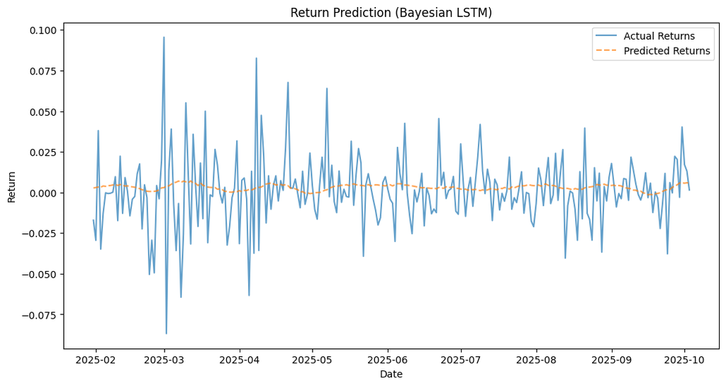

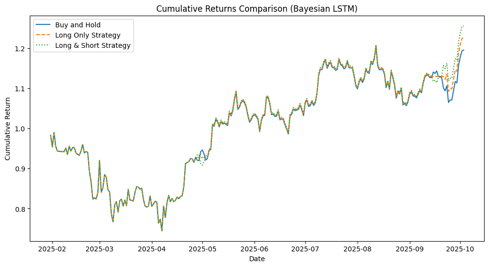

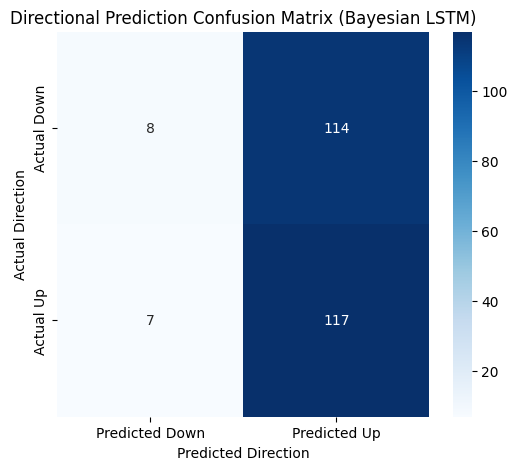

```
Metrics dictionary returned by the function:
{'long_only_sharpe': np.float64(0.781041962880524), 'long_short_sharpe': np.float64(0.8481306078316365), 'buy_hold_sharpe': np.float64(0.7012185019140329), 'accuracy': 0.508130081300813}
```

```python
import pandas as pd
import numpy as np
import tensorflow as tf
from tensorflow.keras.models import Sequential
from tensorflow.keras.layers import LSTM, Dense, Dropout
from sklearn.preprocessing import MinMaxScaler

def create_sequences(data, n_steps):
    X, y = [], []
    for i in range(len(data)):
        end_ix = i + n_steps
        if end_ix > len(data) - 1:
            break
        # The input sequence is now all feature columns
        seq_x, seq_y = data[i:end_ix, :-1], data[end_ix, -1]
        X.append(seq_x)
        y.append(seq_y)
    return np.array(X), np.array(y)

# --- 1. Data and Feature Engineering ---
# Start with daily features, not lagged features
data = btc_gold_sp_close_cleaned_returns[['date', 'btc_close', 'btc_return']].copy()
data['date'] = pd.to_datetime(data['date'])

# Create a few daily technical indicators as features
data['volatility_14'] = data['btc_return'].rolling(window=14).std()
delta = data['btc_close'].diff()
gain = (delta.where(delta > 0, 0)).rolling(window=14).mean()
loss = (-delta.where(delta < 0, 0)).rolling(window=14).mean()
rs = gain / loss
data['rsi_14'] = 100 - (100 / (1 + rs))

# Create the target variable and clean the data
data['Next_Return'] = data['btc_return'].shift(-1)
data = data.dropna().reset_index(drop=True)

# Define training and testing periods
train_df = data[data['date'].between('2023-01-01', '2024-12-31')]
test_df = data[data['date'].between('2025-01-01', '2025-12-31')]

# Define the features to be used in the sequence
feature_cols = ['btc_return', 'volatility_14', 'rsi_14']
x_scaler = MinMaxScaler(feature_range=(0, 1))
X_train_scaled = x_scaler.fit_transform(train_df[feature_cols])
X_test_scaled = x_scaler.transform(test_df[feature_cols])

y_scaler = MinMaxScaler(feature_range=(0, 1))
y_train_scaled = y_scaler.fit_transform(train_df[['Next_Return']])
y_test_scaled = y_scaler.transform(test_df[['Next_Return']])

# --- 2. Create Sequences ---
train_data = np.hstack((X_train_scaled, y_train_scaled))
test_data = np.hstack((X_test_scaled, y_test_scaled))

n_steps = 30 # Use a sequence of the last 30 days of features
X_train_lstm, y_train_lstm = create_sequences(train_data, n_steps)
X_test_lstm, y_test_lstm = create_sequences(test_data, n_steps)

# --- 3. Build and Train LSTM Model ---
model_lstm = Sequential([
    LSTM(units=50, return_sequences=True, input_shape=(n_steps, X_train_lstm.shape[2])),
    Dropout(0.2),
    LSTM(units=50),
    Dropout(0.2),
    Dense(units=1),
    Dropout(0.2),
    Dense(units=1)
])
model_lstm.compile(optimizer='adam', loss='mean_squared_error')
model_lstm.fit(X_train_lstm, y_train_lstm, epochs=50, batch_size=32, verbose=0)

# --- 4. Predict using MC-Dropout and Inverse Scale ---
def mc_dropout_predict(model, X, samples=100):
    """Performs Monte Carlo Dropout predictions."""
    predictions = np.zeros((samples, X.shape[0]))
    for i in range(samples):
        # Make a prediction with dropout ACTIVE by setting training=True
        predictions[i, :] = model(X, training=True).numpy().flatten()
    return predictions

# Get the distribution of predictions
mc_predictions_scaled = mc_dropout_predict(model_lstm, X_test_lstm)

# The final prediction is the mean of the distribution
y_pred_scaled = np.mean(mc_predictions_scaled, axis=0)

# Inverse scale the results
y_pred = y_scaler.inverse_transform(y_pred_scaled.reshape(-1, 1)).flatten()
y_test = y_scaler.inverse_transform(y_test_lstm.reshape(-1, 1)).flatten()


# --- 5. Align DataFrame and Analyze ---
test_df_lstm = test_df.iloc[n_steps:].copy()
# Note: The model name is changed to reflect the Bayesian method
metrics = analyze_model_performance(test_df_lstm, y_test, y_pred, model_name='Bayesian LSTM')

print("\nMetrics dictionary returned by the function:")
print(metrics)
```

### Volatility Modeling with ARMA–GARCH

Finally, we employ a **hybrid ARMA–GARCH model** to capture both the **serial correlation** and **time-varying volatility** in Bitcoin returns.  
This approach blends autoregressive structure for the mean with conditional heteroskedasticity for the variance — a standard tool in financial econometrics.

**Model specification**

The return process is modeled as:

$$ r_t = \mu + \sum_{i=1}^{p} \phi_i r_{t-i} + \varepsilon_t, \qquad \varepsilon_t = \sigma_t z_t, $$

with the conditional variance following a **GARCH(1,1)** process:

$$ \sigma_t^2 = \omega + \alpha_1 \varepsilon_{t-1}^2 + \beta_1 \sigma_{t-1}^2, $$

where $z_t$ are standardized residuals drawn from a Student’s-$t$ distribution.

We also include multiple autoregressive lags ($p=60$) to test whether **past returns contain predictive power** for the mean process.

**Training and testing**

- **Train:** 2023–2024
- **Test:** 2025
- Returns are scaled by 100 for numerical stability.

The model is fitted using the `arch` library (`mean='ARX'`, `vol='Garch'`, `p=1`, `q=1`, `dist='t'`).

**Interpretation of results**

We then refit the model using only these **significant lags** to focus on the most informative predictors and reduce noise.

**Why ARMA–GARCH?**

- AR terms capture **predictable patterns** in mean returns.
- GARCH terms capture **volatility clustering**, a key property of financial series.
- Together, they provide a dynamic forecast of both **expected return** and **risk** over time.

> The ARMA–GARCH model reveals that certain days (e.g., lag 1, 25, 60) have **statistically significant predictive power**, implying  
> that Bitcoin’s return dynamics exhibit structured temporal dependencies rather than being purely random.

```
                              AR - GARCH Model Results
====================================================================================
Dep. Variable:                   btc_return   R-squared:                       0.051
Mean Model:                              AR   Adj. R-squared:                 -0.043
Vol Model:                            GARCH   Log-Likelihood:               -1496.33
Distribution:      Standardized Student's t   AIC:                           3122.66
Method:                  Maximum Likelihood   BIC:                           3415.73
                                              No. Observations:                  671
Date:                      Wed, Oct 15 2025   Df Residuals:                      610
Time:                              10:01:13   Df Model:                           61
                                    Mean Model
==================================================================================
                      coef    std err          t      P>|t|       95.0% Conf. Int.
----------------------------------------------------------------------------------
Const               0.1034  9.994e-02      1.034      0.301   [-9.253e-02,  0.299]
btc_return[1]      -0.0788  3.651e-02     -2.160  3.079e-02   [ -0.150,-7.293e-03]
btc_return[2]       0.0385  3.414e-02      1.128      0.259   [-2.841e-02,  0.105]
btc_return[3]      -0.0358  3.400e-02     -1.054      0.292    [ -0.102,3.079e-02]
btc_return[4]       0.0337  3.595e-02      0.937      0.349   [-3.678e-02,  0.104]
btc_return[5]  -2.2704e-03  3.441e-02 -6.598e-02      0.947 [-6.972e-02,6.518e-02]
btc_return[6]      -0.0121  3.571e-02     -0.340      0.734 [-8.214e-02,5.786e-02]
btc_return[7]  -4.8104e-03  3.491e-02     -0.138      0.890 [-7.324e-02,6.362e-02]
btc_return[8]      -0.0173  3.500e-02     -0.494      0.621 [-8.590e-02,5.132e-02]
btc_return[9]       0.0339  3.558e-02      0.952      0.341   [-3.587e-02,  0.104]
btc_return[10]      0.0216  4.140e-02      0.523      0.601   [-5.950e-02,  0.103]
btc_return[11]     -0.0276  2.980e-02     -0.925      0.355 [-8.598e-02,3.084e-02]
btc_return[12]     -0.0183  3.435e-02     -0.534      0.593 [-8.567e-02,4.898e-02]
btc_return[13]      0.0158  3.708e-02      0.427      0.670 [-5.685e-02,8.848e-02]
btc_return[14]      0.0114  3.963e-02      0.289      0.773 [-6.624e-02,8.910e-02]
btc_return[15]  4.8111e-03  3.783e-02      0.127      0.899 [-6.934e-02,7.896e-02]
btc_return[16] -1.4767e-03  3.218e-02 -4.589e-02      0.963 [-6.455e-02,6.160e-02]
btc_return[17]  8.1983e-03  3.205e-02      0.256      0.798 [-5.461e-02,7.101e-02]
btc_return[18]      0.0157  3.248e-02      0.483      0.629 [-4.798e-02,7.935e-02]
btc_return[19]     -0.0328  3.207e-02     -1.022      0.307 [-9.565e-02,3.007e-02]
btc_return[20]     -0.0451  3.106e-02     -1.452      0.146    [ -0.106,1.578e-02]
btc_return[21]  9.3718e-03  3.736e-02      0.251      0.802 [-6.384e-02,8.259e-02]
btc_return[22]  3.6658e-03  3.319e-02      0.110      0.912 [-6.139e-02,6.872e-02]
btc_return[23]      0.0242  3.714e-02      0.651      0.515 [-4.860e-02,9.696e-02]
btc_return[24]      0.0316  3.500e-02      0.903      0.366   [-3.698e-02,  0.100]
btc_return[25]      0.0850  3.285e-02      2.587  9.686e-03    [2.059e-02,  0.149]
```

[output cut: 45 more lines]

```
------------------------------------------------------------------------
nu             2.8943      0.372      7.777  7.441e-15 [  2.165,  3.624]
========================================================================

Covariance estimator: robust
--- Performance for ARMA-GARCH ---
Sharpe Ratio (Long Only): 1.347
Sharpe Ratio (Long & Short): 1.674
Sharpe Ratio (Buy and Hold): 0.881
Directional Accuracy: 51.99%

Confusion Matrix:
 [[ 15 121]
 [ 12 129]]
------------------------------
```

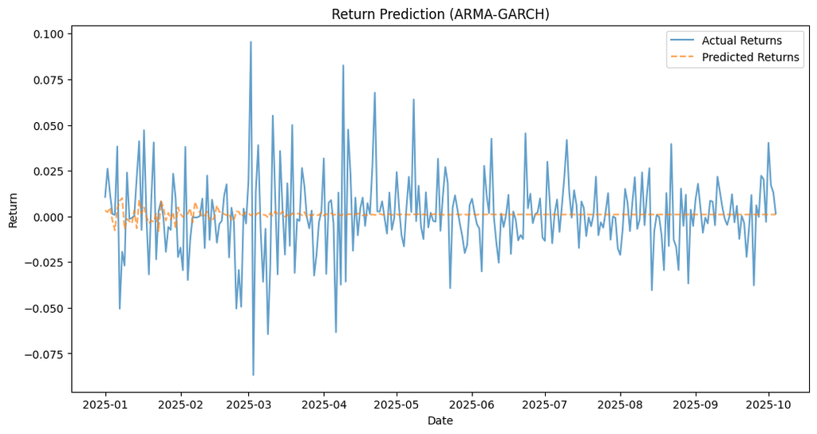

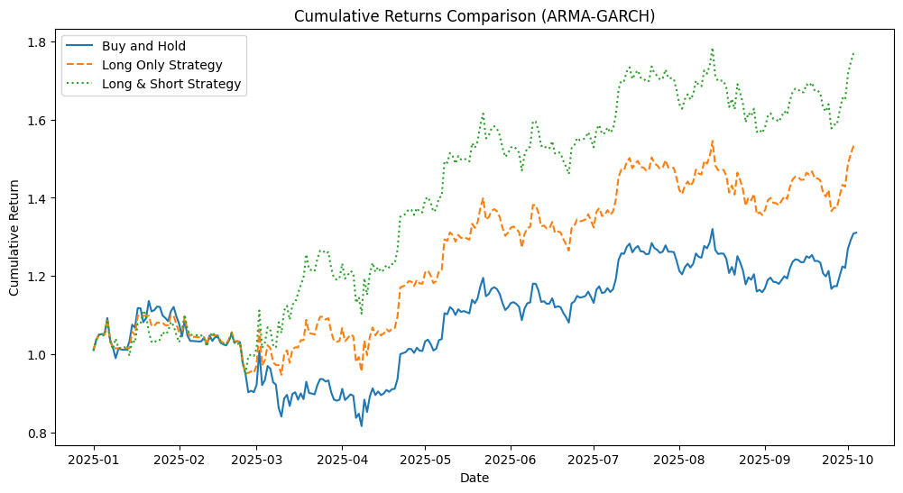

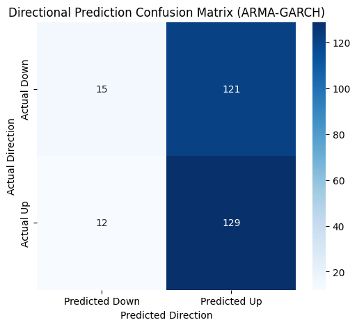

```
Metrics dictionary returned by the function:
{'long_only_sharpe': np.float64(1.3472223863175923), 'long_short_sharpe': np.float64(1.6743451908034426), 'buy_hold_sharpe': np.float64(0.8808677039162768), 'accuracy': 0.51985559566787}
                              AR - GARCH Model Results
====================================================================================
Dep. Variable:                   btc_return   R-squared:                       0.011
Mean Model:                              AR   Adj. R-squared:                  0.006
Vol Model:                            GARCH   Log-Likelihood:               -1515.90
Distribution:      Standardized Student's t   AIC:                           3047.80
Method:                  Maximum Likelihood   BIC:                           3083.87
                                              No. Observations:                  671
Date:                      Wed, Oct 15 2025   Df Residuals:                      667
Time:                              10:01:14   Df Model:                            4
                                   Mean Model
===============================================================================
                     coef    std err          t      P>|t|     95.0% Conf. Int.
-------------------------------------------------------------------------------
Const              0.0958  7.726e-02      1.241      0.215 [-5.557e-02,  0.247]
btc_return[1]     -0.0769  3.539e-02     -2.172  2.985e-02 [ -0.146,-7.509e-03]
btc_return[25]     0.0700  2.975e-02      2.353  1.862e-02  [1.170e-02,  0.128]
btc_return[60]    -0.0605  2.529e-02     -2.393  1.672e-02 [ -0.110,-1.094e-02]
                              Volatility Model
============================================================================
                 coef    std err          t      P>|t|      95.0% Conf. Int.
----------------------------------------------------------------------------
omega          0.0612      0.162      0.377      0.706     [ -0.257,  0.379]
alpha[1]       0.0389  1.299e-02      2.996  2.739e-03 [1.346e-02,6.439e-02]
beta[1]        0.9611  2.682e-02     35.833 3.338e-281     [  0.909,  1.014]
                              Distribution
========================================================================
                 coef    std err          t      P>|t|  95.0% Conf. Int.
------------------------------------------------------------------------
nu             2.9823      0.359      8.313  9.302e-17 [  2.279,  3.685]
========================================================================

Covariance estimator: robust
--- Performance for ARMA-GARCH ---
Sharpe Ratio (Long Only): 1.000
Sharpe Ratio (Long & Short): 1.064
Sharpe Ratio (Buy and Hold): 0.881
Directional Accuracy: 50.54%

Confusion Matrix:
 [[ 10 126]
 [ 11 130]]
------------------------------
```

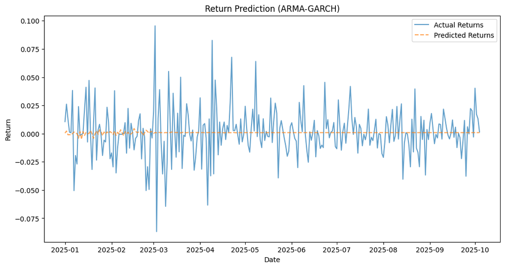

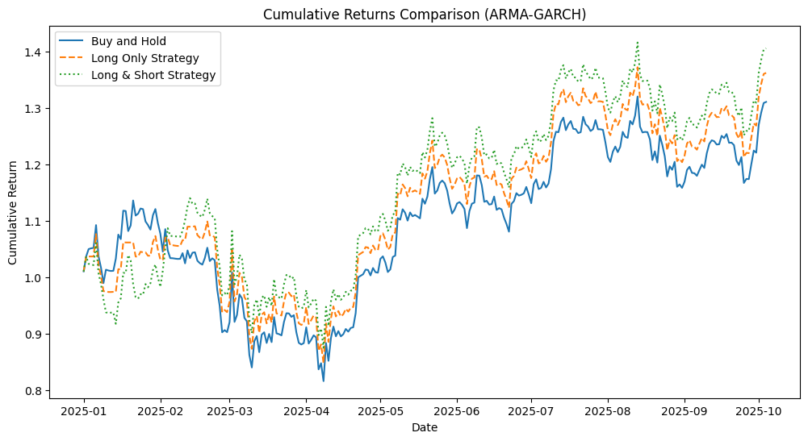

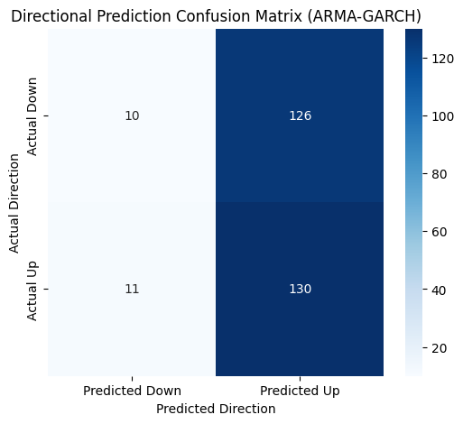

```python
import pandas as pd
import numpy as np
from arch import arch_model
import matplotlib.pyplot as plt
import seaborn as sns


data = btc_gold_sp_close_cleaned_returns[['date', 'btc_return']].copy()
data['date'] = pd.to_datetime(data['date'])

# **FIX**: Add this line to remove any NaN values from the return calculation
data = data.dropna()

data.set_index('date', inplace=True)

# Split the return series chronologically
train_returns = data.loc['2023-01-01':'2024-12-31']['btc_return']
test_returns = data.loc['2025-01-01':'2025-12-31']['btc_return']

# Also create a test_df for the analysis function
test_df = data.loc['2025-01-01':'2025-12-31'].reset_index()
test_df['Next_Return'] = test_returns.values

# --- 2. Model Training ---
scaled_train_returns = train_returns * 100

model = arch_model(scaled_train_returns, mean='ARX', lags=60, vol='Garch', p=1, q=1, dist='t')
results = model.fit(disp='off')

# Print the summary to see the new ARMA coefficients
print(results.summary())

# --- 3. Forecasting ---
forecasts = results.forecast(horizon=len(test_returns))

y_pred = forecasts.mean.iloc[-1].values / 100
y_test = test_returns.values

# --- 4. Analysis and Visualization ---
metrics = analyze_model_performance(test_df, y_test, y_pred, model_name='ARMA-GARCH')

print("\nMetrics dictionary returned by the function:")
print(metrics)

significant_lags = [1, 25, 60]

# Re-run the model with just these features
model = arch_model(scaled_train_returns, mean='ARX', lags=significant_lags, vol='Garch', p=1, q=1, dist='t')
results = model.fit(disp='off')

# Print the new, cleaner summary
print(results.summary())

# --- 3. Forecasting ---
forecasts = results.forecast(horizon=len(test_returns))

y_pred = forecasts.mean.iloc[-1].values / 100
y_test = test_returns.values

# --- 4. Analysis and Visualization ---
metrics = analyze_model_performance(test_df, y_test, y_pred, model_name='ARMA-GARCH')
```

### Inter-Market Modeling with XGBoost

We extend our model to include **cross-asset influences** from **Gold** and the **S&P 500**, recognizing that Bitcoin’s price often reacts to global risk sentiment and safe-haven flows.

We construct a multivariate lag space using 14 days of historical returns for all three assets:

$$ \mathbf{x}_t = [\text{BTC}_{t-1:t-14},\ \text{GOLD}_{t-1:t-14},\ \text{S\&P}_{t-1:t-14}] $$

The model predicts Bitcoin’s next-day return: $$ \hat{r}_{t+1}^{BTC} = f_{\text{XGB}}(\mathbf{x}_t) $$

where $f_{\text{XGB}}$ is a gradient-boosted regression tree ensemble.  
By including other markets, we test whether Bitcoin behaves more like a **risk-on** (correlated with equities) or **risk-off** (correlated with gold) asset.  
The model is trained on 2023–2024 and tested on 2025, using the same trading strategy evaluation via **Sharpe ratio**, **directional accuracy**, and **cumulative returns**.

```
--- Performance for XGBoost (Inter-Market) ---
Sharpe Ratio (Long Only): 0.857
Sharpe Ratio (Long & Short): 0.395
Sharpe Ratio (Buy and Hold): 0.855
Directional Accuracy: 50.36%

Confusion Matrix:
 [[58 78]
 [59 81]]
------------------------------
```

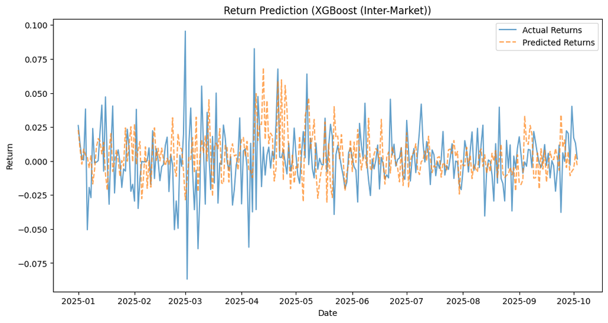

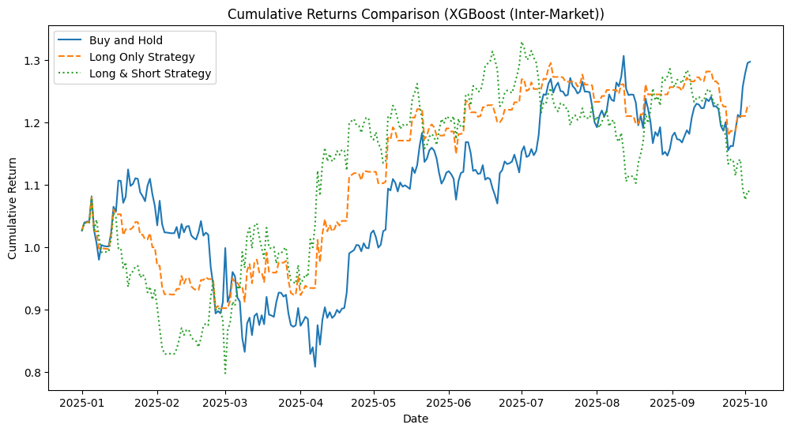

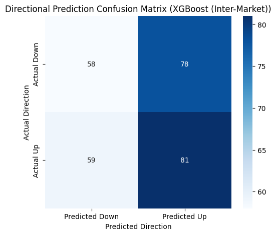

```
Metrics dictionary returned by the function:
{'long_only_sharpe': np.float64(0.8573644542690346), 'long_short_sharpe': np.float64(0.3947081170118581), 'buy_hold_sharpe': np.float64(0.8549789775309998), 'accuracy': 0.5036231884057971}
```

```python
import pandas as pd
import numpy as np
from xgboost import XGBRegressor

# Assume btc_gold_sp_close_cleaned_returns and analyze_model_performance are defined

# --- 1. Data and Feature Engineering ---
# Select the returns from all three assets
data = btc_gold_sp_close_cleaned_returns[['date', 'btc_return', 'gold_return', 'snp_return']].copy()
data['date'] = pd.to_datetime(data['date'])

num_lags = 14 # Let's use 14 days of history for each asset

# Create lagged features for all three assets
for lag in range(1, num_lags + 1):
    data[f'btc_lag_{lag}'] = data['btc_return'].shift(lag)
    data[f'gold_lag_{lag}'] = data['gold_return'].shift(lag)
    data[f'snp_lag_{lag}'] = data['snp_return'].shift(lag)

# Create the target variable (Bitcoin's next-day return)
data['Next_Return'] = data['btc_return'].shift(-1)
data = data.dropna().reset_index(drop=True)

# --- 2. Training and Prediction ---
train_df = data[data['date'].between('2023-01-01', '2024-12-31')]
test_df = data[data['date'].between('2025-01-01', '2025-12-31')]

# Create a comprehensive list of all feature columns
btc_lags = [f'btc_lag_{i}' for i in range(1, num_lags + 1)]
gold_lags = [f'gold_lag_{i}' for i in range(1, num_lags + 1)]
snp_lags = [f'snp_lag_{i}' for i in range(1, num_lags + 1)]
feature_cols = btc_lags + gold_lags + snp_lags

X_train = train_df[feature_cols].values
y_train = train_df['Next_Return'].values
X_test = test_df[feature_cols].values
y_test = test_df['Next_Return'].values

model = XGBRegressor(n_estimators=300, max_depth=4, random_state=42, n_jobs=-1)
model.fit(X_train, y_train)
y_pred = model.predict(X_test)

# --- 3. Analysis and Visualization ---
metrics = analyze_model_performance(test_df, y_test, y_pred, model_name='XGBoost (Inter-Market)')

print("\nMetrics dictionary returned by the function:")
print(metrics)
```

## Model Performance Summary

Below we compare the performance of all tested models under three strategies:  
**Long Only**, **Long & Short**, and the baseline **Buy & Hold**.

[output not shown]

### Summary of Model Performances

Across all models, the **MLP Regressor** achieved the best performance, with the highest Sharpe ratios for both **Long Only (2.218)** and **Long & Short (2.349)** strategies.  
This indicates strong nonlinear learning capability and robustness, despite only moderate directional accuracy (55~%). This trend can also be observed for the Tuned ANN (Scaled) model, which delivers competitive results compared to the other models.